# Part B · Token-Level EDA

## Pipeline Position

| Part | Notebook | GPU Required | Input | Output |
| --- | --- | --- | --- | --- |
| A | part_a_translation_evaluation | Yes (T4) | FLoRes-200 dataset | sacrebleu_results.csv |
| **B** | **part_b_token_eda** | **No (CPU)** | **sacrebleu_results.csv** | **token_counts.csv, engineered_features.csv** |
| C | part_c_indic_token_analysis | No (CPU) | token_counts.csv | Vocabulary coverage charts |

## What This Notebook Measures

| Metric | Definition | Why It Matters |
| --- | --- | --- |
| `expansion_ratio` | Target tokens ÷ Source tokens | Measures verbosity of the tokeniser for Tamil |
| `avg_word_length` | Tamil chars ÷ Target token count | Higher = fewer fragmented subwords |
| `subword_fragmentation` | 1 ÷ avg_word_length | Proxy for aggressive subword splitting |
| `unknown_token_rate` | % tokens mapped to UNK | Measures out-of-vocabulary exposure |

## Why Token Analysis Matters Beyond BLEU

BLEU measures surface-level n-gram overlap — it does not reveal **how** a model internally represents Tamil text. Two models with similar BLEU scores can have drastically different tokenisation behaviours:

- A model may fragment every Tamil word into 4–6 tiny subwords, bloating sequence length and increasing attention memory cost
- Another model may encode the same sentence in half the tokens, with richer information per token

These tokenisation differences affect:

- **Transformer attention memory** — O(n²) cost scales with sequence length squared
- **Information density** — longer tokens carry more morphological signal
- **Agglutination handling** — Tamil verbs like வந்திருக்கிறான் ("he has come") encode 4+ morphemes in one word; a poor tokeniser cannot represent this as a single meaningful unit

**Data source:** `../part_a_batch_translation/sacrebleu_results.csv` — 100 FLoRes-200 English–Tamil sentence pairs with translations from all 5 models.

## Model Reference

| Model | Size | Tokeniser Type | Tamil Focus |
| --- | --- | --- | --- |
| IndicTrans2 | 1B | SentencePiece (22 Indic langs) | High |
| NLLB-200 | 600M | SentencePiece (200 langs) | Moderate |
| mT5 | 580M | SentencePiece (101 langs) | Low (tokeniser analysis only) |
| Helsinki MarianMT | 74M | SentencePiece (EN→Dravidian: ta/kn/ml/te) | High |
| MADLAD-400 | 3B | SentencePiece (400 langs) | Low (extreme dilution) |

## Section 1 · Environment Setup

**CPU-only notebook** — no GPU required for tokenisation. All five tokenisers run as CPU-bound string operations; no matrix multiplications are needed to tokenise text.

**Why a consistent colour palette?** All three notebooks (A, B, C) use the same `MODEL_COLORS` dictionary keyed by model name. This ensures that IndicTrans2 is always `#2E86AB` (blue), NLLB-200 is always `#A23B72` (purple), and so on across every chart in the project. A reviewer comparing plots across notebooks can identify models at a glance without reading the legend each time.

```python
# ── Cell 0 · Runtime check + global visual theme ──────────────────────────────
import subprocess, sys, os, gc, torch, warnings
import matplotlib.pyplot as plt
import matplotlib.patches as mpatches
import seaborn as sns
import numpy as np
import pandas as pd
from IPython.display import display, HTML
warnings.filterwarnings("ignore")

print("Python :", sys.version)
print("PyTorch:", torch.__version__)
print("CUDA   :", torch.cuda.is_available())
DEVICE = "cuda" if torch.cuda.is_available() else "cpu"
os.makedirs("plots", exist_ok=True)

PALETTE = ["#2E86AB", "#A23B72", "#F18F01", "#C73E1D", "#3B1F2B"]
MODEL_COLORS = {
    "IndicTrans2" : "#2E86AB",
    "NLLB-200"    : "#A23B72",
    "mT5"         : "#F18F01",
    "Helsinki"    : "#C73E1D",
    "MADLAD"      : "#3B1F2B",
}
sns.set_theme(style="whitegrid", font_scale=1.1)
plt.rcParams.update({
    "figure.dpi": 150, "figure.facecolor": "white",
    "axes.spines.top": False, "axes.spines.right": False,
    "font.family": "DejaVu Sans",
})
print("\u2713 Global theme applied")
```

```
Python : 3.11.9 (tags/v3.11.9:de54cf5, Apr  2 2024, 10:12:12) [MSC v.1938 64 bit (AMD64)]
PyTorch: 2.12.0+cpu
CUDA   : False
✓ Global theme applied
```

## Why mT5 Is Included Here (but Not in BLEU Evaluation)

mT5 is a **masked seq2seq pre-training model** — it was trained to reconstruct corrupted input spans, not to translate from English to Tamil. Its raw decoded outputs are not meaningful translations and would score near zero on sacreBLEU.

## Section 2 · Loading Tokenisers

We load only the **tokeniser weights** — not the full model — using `AutoTokenizer.from_pretrained()`. This is fast (seconds per tokeniser) and requires no GPU.

[output not shown]

```python
# ── Cell 1 · HuggingFace authentication + compatibility shims ─────────────────
import os, sys, types, subprocess
from pathlib import Path

# ── 1. Load .env (local runs) ──────────────────────────────────────────────────
try:
    from dotenv import load_dotenv, find_dotenv
    dotenv_path = find_dotenv(usecwd=False)
    if dotenv_path:
        load_dotenv(dotenv_path, override=False)
        print(f"✓ Loaded .env from: {dotenv_path}")
    else:
        print("⚠ No .env file found — relying on environment variables")
except ImportError:
    print("⚠ python-dotenv not installed — run: pip install python-dotenv")

hf_token = os.environ.get("HF_TOKEN")
if hf_token:
    from huggingface_hub import login
    login(token=hf_token, add_to_git_credential=False)
    print("✓ Authenticated with HuggingFace Hub")
else:
    print("⚠ HF_TOKEN not set — gated repos (e.g. IndicTrans2) will fail")

# ── 2. Ensure protobuf is present ──────────────────────────────────────────────
# Some models (NLLB-200, MADLAD) expose a fast tokenizer whose loading path
# calls SentencePieceExtractor, which requires protobuf to read the .model file.
try:
    import google.protobuf
    print("✓ protobuf already available")
except ImportError:
    print("Installing protobuf …")
    subprocess.run(
        [sys.executable, "-m", "pip", "install", "protobuf>=3.20.0", "-q"],
        check=True,
    )
    print("✓ protobuf installed — kernel restart NOT needed")

# ── 3. transformers.onnx stub ──────────────────────────────────────────────────
# transformers.onnx was removed in ≥4.40; IndicTrans2 remote config still
# imports it. Inject a minimal stub so the import succeeds.
if "transformers.onnx" not in sys.modules:
    _onnx_mod = types.ModuleType("transformers.onnx")
    class OnnxConfig: pass
    class OnnxSeq2SeqConfigWithPast: pass
    _onnx_mod.OnnxConfig = OnnxConfig
    _onnx_mod.OnnxSeq2SeqConfigWithPast = OnnxSeq2SeqConfigWithPast
    sys.modules["transformers.onnx"] = _onnx_mod

if "transformers.onnx.utils" not in sys.modules:
    _onnx_utils = types.ModuleType("transformers.onnx.utils")
    def compute_effective_axis_dimension(*args, **kwargs): return 0
    _onnx_utils.compute_effective_axis_dimension = compute_effective_axis_dimension
    sys.modules["transformers.onnx.utils"] = _onnx_utils

print("✓ transformers.onnx compatibility shim installed")
```

```
✓ Loaded .env from: d:\Projects\tamizh\indic-translation-asr-project\.env
```

```
Note: Environment variable`HF_TOKEN` is set and is the current active token independently from the token you've just configured.
```

```
✓ Authenticated with HuggingFace Hub
✓ protobuf already available
✓ transformers.onnx compatibility shim installed
```

```python
# ── Cell 2 · Load tokenizers (no model weights) ───────────────────────────────
from transformers import AutoTokenizer

# use_fast=False for all non-IndicTrans2 models: avoids protobuf/tiktoken
# dependencies that the fast-tokenizer conversion path requires but are not
# installed in a CPU-only analysis environment.
TOKENIZER_IDS = {
    "IndicTrans2": ("ai4bharat/indictrans2-en-indic-1B", {"trust_remote_code": True}),
    "NLLB-200":    ("facebook/nllb-200-distilled-600M",  {"use_fast": False}),
    "mT5":         ("google/mt5-base",                   {"use_fast": False}),
    "Helsinki":    ("Helsinki-NLP/opus-mt-en-dra",       {"use_fast": False}),
    "MADLAD":      ("google/madlad400-3b-mt",            {"use_fast": False}),
}

tokenizers = {}
for name, (model_id, kwargs) in TOKENIZER_IDS.items():
    print(f"Loading tokenizer: {name}")
    tokenizers[name] = AutoTokenizer.from_pretrained(model_id, **kwargs)
    print(f"  ✓ Vocab size: {tokenizers[name].vocab_size:,}")
```

```
Loading tokenizer: IndicTrans2
  ✓ Vocab size: 32,322
Loading tokenizer: NLLB-200
  ✓ Vocab size: 256,204
Loading tokenizer: mT5
  ✓ Vocab size: 250,100
Loading tokenizer: Helsinki
  ✓ Vocab size: 62,952
Loading tokenizer: MADLAD
  ✓ Vocab size: 256,000
```

## Section 3 · Data Handoff from Part A

Part B reads the CSV saved by Part A. Expected schema:

| Column | Description |
| --- | --- |
| `source_english` or `english` | Original English sentence from FLoRes-200 devtest |
| `reference_tamil` | Human-verified Tamil reference translation |
| `pred_IndicTrans2` | IndicTrans2 model output |
| `pred_NLLB-200` | NLLB-200-distilled-600M output |
| `pred_Helsinki` | Helsinki MarianMT en-dra output |
| `pred_MADLAD` | MADLAD-400-3b-mt output |
| `pred_mT5` | mT5-base raw decoded output (not a translation) |

**Column name handling:** The blueprint specifies `english` but our Part A saves the column as `source_english`. The load cell handles both variants with a conditional check — if Part A is re-run with the blueprint column name, Part B continues to work without modification.

**mT5 note:** `pred_mT5` contains text decoded from the mT5 model without any translation fine-tuning. The actual decoded strings are not meaningful Tamil translations, but we tokenise them through the mT5 tokeniser to measure how mT5 handles Tamil text regardless of decoding quality.

```python
# ── Cell 3 · Load Part A translations ─────────────────────────────────────────
df_parta = pd.read_csv("../part_a_batch_translation/sacrebleu_results.csv")
print(f"\u2713 Loaded Part A results: {len(df_parta)} rows")
print(f"  Columns: {list(df_parta.columns)}")

# Handle column name difference between blueprint ("english") and our Part A ("source_english")
eng_col = "english" if "english" in df_parta.columns else "source_english"
sentences_en = df_parta[eng_col].tolist()

model_outputs = {
    "IndicTrans2": df_parta["pred_IndicTrans2"].tolist(),
    "NLLB-200":   df_parta["pred_NLLB-200"].tolist(),
    "Helsinki":   df_parta["pred_Helsinki"].tolist(),
    "MADLAD":     df_parta["pred_MADLAD"].tolist(),
    "mT5":        df_parta["pred_mT5"].tolist(),
}
print("\u2713 All 5 model outputs loaded (including mT5 for tokenization analysis)")
```

```
✓ Loaded Part A results: 100 rows
  Columns: ['source_english', 'reference_tamil', 'pred_Helsinki', 'pred_mT5', 'pred_NLLB-200', 'pred_IndicTrans2', 'pred_MADLAD', 'bleu_Helsinki', 'bleu_NLLB-200', 'bleu_IndicTrans2', 'bleu_MADLAD']
✓ All 5 model outputs loaded (including mT5 for tokenization analysis)
```

## Section 4 · Token Metrics Computation

Each of the 100 English sentences and its 5 corresponding Tamil translations is passed through each model's tokeniser. We compute 4 core metrics per sentence per model (500 total measurements):

| Metric | Formula | Interpretation |
| --- | --- | --- |
| `expansion_ratio` | target_tokens ÷ source_tokens | >1.0 = Tamil is more verbose than English in this tokeniser |
| `avg_word_length` | tamil_chars ÷ target_tokens | Higher = larger, more meaningful subword units |
| `subword_fragmentation` | 1 ÷ avg_word_length | Higher = finer-grained splitting; harder for the model to decode |
| `unknown_token_rate` | (UNK_count ÷ target_tokens) × 100 | Higher = more out-of-vocabulary Tamil words |

**Why `encode()` instead of `tokenize()`?** We use `tokenizer.encode()` (returns integer token IDs) rather than `tokenizer.tokenize()` (returns string tokens) specifically to detect UNK tokens. An UNK is identified by comparing each ID to `tokenizer.unk_token_id`. String-based `tokenize()` returns `<unk>` as a plain string, which cannot be reliably distinguished from a genuine vocabulary token also named `<unk>` — a subtle but real edge case in some tokeniser implementations.

**Tamil character counting** strips whitespace before dividing by token count. Tamil is written with no spaces between characters within a word, so the raw character count directly measures how many Tamil script code points each token encodes on average. A higher value means each token carries more linguistic content.

```python
# ── Cell 4 · Compute token metrics ────────────────────────────────────────────
def compute_token_metrics(text_en, text_ta, tokenizer, model_name=None):
    if model_name == "IndicTrans2":
        # IndicTrans2 _src_tokenize requires "src_lang tgt_lang text" format
        src_tokens = tokenizer.encode(
            f"eng_Latn tam_Taml {text_en}", add_special_tokens=False
        )
        # Switch to target mode so Tamil text is encoded with the target SPM
        tokenizer._switch_to_target_mode()
        tgt_tokens = tokenizer.encode(text_ta, add_special_tokens=False)
        tokenizer._switch_to_input_mode()
    else:
        src_tokens = tokenizer.encode(text_en, add_special_tokens=False)
        tgt_tokens = tokenizer.encode(text_ta, add_special_tokens=False)

    src_count = max(len(src_tokens), 1)
    tgt_count = max(len(tgt_tokens), 1)
    unk_id = tokenizer.unk_token_id
    unk_rate = (tgt_tokens.count(unk_id) / tgt_count * 100) if unk_id else 0.0
    tamil_chars = len(str(text_ta).replace(" ", ""))
    avg_chars_per_tok = tamil_chars / tgt_count
    subword_frag = round(1 / avg_chars_per_tok, 4) if avg_chars_per_tok > 0 else 0
    return {
        "source_token_count": src_count,
        "target_token_count": tgt_count,
        "expansion_ratio": round(tgt_count / src_count, 3),
        "avg_word_length": round(avg_chars_per_tok, 3),
        "subword_fragmentation": subword_frag,
        "unknown_token_rate": round(unk_rate, 3),
    }


records = []
for model_name, translations in model_outputs.items():
    tok = tokenizers[model_name]
    for idx, (en, ta) in enumerate(zip(sentences_en, translations)):
        metrics = compute_token_metrics(en, str(ta), tok, model_name)
        records.append({"model": model_name, "sentence_id": idx, "english": en, "tamil": ta, **metrics})

token_df = pd.DataFrame(records)
token_df.to_csv("token_counts.csv", index=False)
print(f"✓ Token metrics computed: {len(token_df)} rows")
print(token_df.groupby("model")["expansion_ratio"].mean().round(3))
```

```
[transformers] Token indices sequence length is longer than the specified maximum sequence length for this model (327 > 256). Running this sequence through the model will result in indexing errors
```

```
✓ Token metrics computed: 500 rows
model
Helsinki       0.995
IndicTrans2    5.153
MADLAD         1.606
NLLB-200       1.384
mT5            2.131
Name: expansion_ratio, dtype: float64
```

## Section 5 · Feature Engineering

Three derived features augment the raw metrics to support richer downstream analysis and visualisation:

| Derived Feature | Formula | Purpose |
| --- | --- | --- |
| `log_expansion` | `log1p(expansion_ratio)` | Log-transforms expansion ratio to reduce skew from agglutinated-verb outliers |
| `efficiency_score` | `avg_word_length ÷ expansion_ratio` | Composite quality index: rewards long, information-dense tokens without bloating sequence length |
| `fragmentation_class` | `pd.cut(subword_fragmentation, bins=[0, 0.2, 0.5, 1.0, ∞])` | Categorical label (Low / Medium / High / Very High) for group-level filtering |

```python
# ── Cell 5 · Feature engineering ──────────────────────────────────────────────
token_df["log_expansion"] = np.log1p(token_df["expansion_ratio"])
token_df["efficiency_score"] = token_df["avg_word_length"] / token_df["expansion_ratio"]
token_df["fragmentation_class"] = pd.cut(
    token_df["subword_fragmentation"],
    bins=[0, 0.2, 0.5, 1.0, float("inf")],
    labels=["Low", "Medium", "High", "Very High"],
)
token_df.to_csv("engineered_features.csv", index=False)
print("\u2713 Engineered features saved")
```

```
✓ Engineered features saved
```

## VIZ B1 · Radar Chart — Four-Metric Tokeniser Comparison

**What is being shown:** Each model is drawn as a filled polygon on a 4-axis polar chart. All axes are normalised to [0, 1] so metrics with different units and scales can be compared on the same chart.

**Normalisation direction — outer edge always means better:**

- `avg_word_length` — higher is better → plotted directly (outer = high value = better)
- `expansion_ratio`, `subword_fragmentation`, `unknown_token_rate` — lower is better → each is inverted `(1 − normalised)` before plotting so outer edge still means best performance

**How to read it:**

- A model that fills **more total area** has the strongest all-round tokeniser profile for Tamil
- A model with an **irregular polygon** performs well on some metrics but trades off poorly on others
- **Overlapping polygons** indicate models with similar tokeniser behaviour across multiple dimensions

**Why radar over four separate bar charts?** Bar charts would require 4 separate subplots and multiple legend lookups across them. The radar chart simultaneously shows: (1) absolute normalised performance on each axis, (2) trade-offs between metrics (e.g., great expansion ratio but high UNK rate), and (3) the overall balance of each tokeniser across all four dimensions in a single glance.

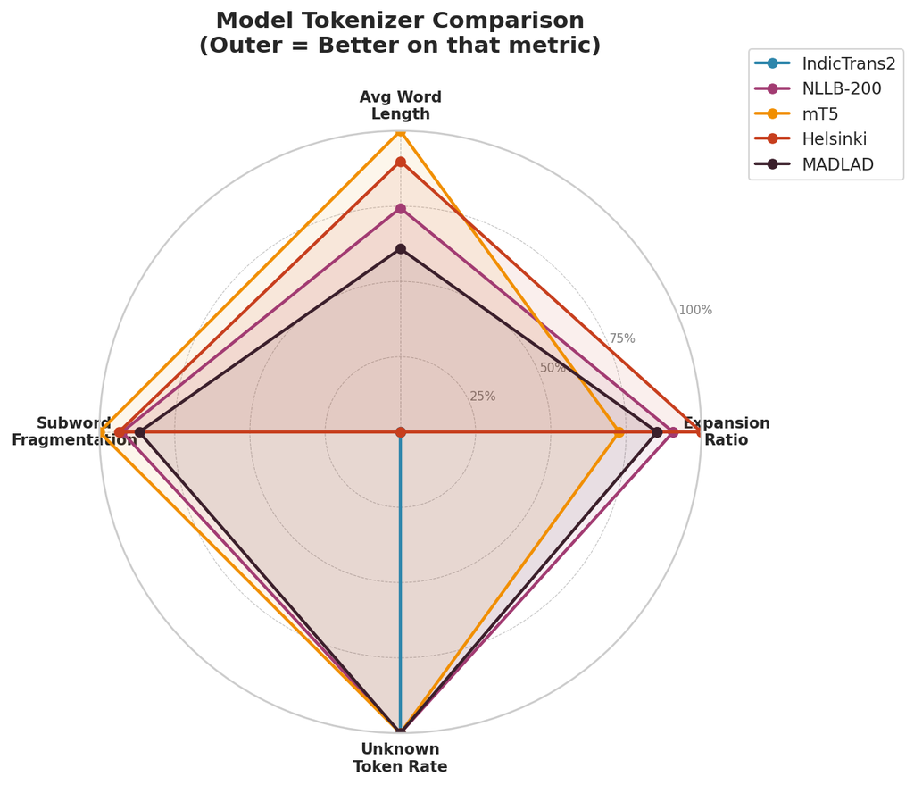

```python
# ── Cell 6 · VIZ B1 · Radar chart (4 tokenizer metrics) ──────────────────────
METRICS = ["expansion_ratio", "avg_word_length", "subword_fragmentation", "unknown_token_rate"]
LABELS  = ["Expansion\nRatio", "Avg Word\nLength", "Subword\nFragmentation", "Unknown\nToken Rate"]
HIGHER_IS_BETTER = [False, True, False, False]

summary = token_df.groupby("model")[METRICS].mean()
norm = summary.copy()
for col, higher in zip(METRICS, HIGHER_IS_BETTER):
    mn, mx = summary[col].min(), summary[col].max()
    if mx == mn:
        norm[col] = 0.5
    elif higher:
        norm[col] = (summary[col] - mn) / (mx - mn)
    else:
        norm[col] = 1 - (summary[col] - mn) / (mx - mn)

N      = len(METRICS)
angles = [n / N * 2 * np.pi for n in range(N)]
angles += angles[:1]

fig, ax = plt.subplots(figsize=(9, 9), subplot_kw=dict(polar=True))
for model_name, color in MODEL_COLORS.items():
    if model_name not in norm.index:
        continue
    values  = norm.loc[model_name].values.flatten().tolist()
    values += values[:1]
    ax.plot(angles, values, "o-", linewidth=2, label=model_name, color=color)
    ax.fill(angles, values, alpha=0.08, color=color)

ax.set_xticks(angles[:-1])
ax.set_xticklabels(LABELS, size=10, fontweight="bold")
ax.set_ylim(0, 1)
ax.set_yticks([0.25, 0.5, 0.75, 1.0])
ax.set_yticklabels(["25%", "50%", "75%", "100%"], size=8, color="grey")
ax.grid(color="grey", linestyle="--", linewidth=0.5, alpha=0.5)
ax.set_title(
    "Model Tokenizer Comparison\n(Outer = Better on that metric)",
    size=15, fontweight="bold", pad=25,
)
ax.legend(loc="upper right", bbox_to_anchor=(1.35, 1.15), fontsize=11)
plt.tight_layout()
plt.savefig("plots/partb_radar_chart.png", bbox_inches="tight", dpi=150)
plt.show()
```

## VIZ B2 · Bubble Chart — Token Expansion per Sentence

**What this chart shows:** Each bubble is one sentence (100 per model). The X-axis encodes source token count (English), the Y-axis encodes target token count (Tamil), and **bubble size is proportional to `expansion_ratio`** for that sentence. All five models are overlaid using the shared MODEL_COLORS palette.

| Region | Interpretation |
| --- | --- |
| Near diagonal | Near-parity expansion; efficient subword segmentation |
| Far above diagonal | High expansion; model fragments Tamil words into many pieces |
| Large bubble far above diagonal | Worst-case: long English source AND high fragmentation combined |
| Vertical scatter within one model | Inconsistent behaviour; some sentence types are handled better than others |

**Design choice — bubble chart over a line plot:** Aggregating across sentences hides the sentence-level variance that reveals fragmentation hot-spots. The bubble chart preserves all 100 data points per model while the size encoding adds a third dimension without a separate subplot.

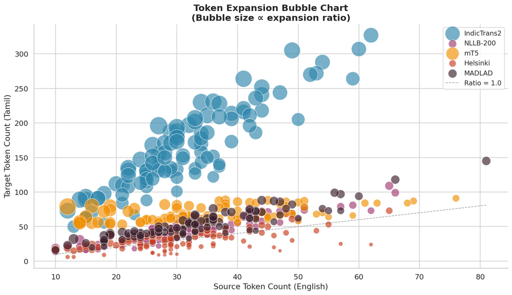

```python
# ── Cell 7 · VIZ B2 · Bubble chart (token expansion) ─────────────────────────
fig, ax = plt.subplots(figsize=(12, 7))
for model_name, color in MODEL_COLORS.items():
    sub = token_df[token_df["model"] == model_name]
    ax.scatter(
        sub["source_token_count"], sub["target_token_count"],
        s=sub["expansion_ratio"] * 120, c=color, alpha=0.65,
        edgecolors="white", linewidths=0.8, label=model_name,
    )

xvals = np.linspace(
    token_df["source_token_count"].min(),
    token_df["source_token_count"].max(),
    100,
)
ax.plot(xvals, xvals, "k--", linewidth=1, alpha=0.4, label="Ratio = 1.0")
ax.set_xlabel("Source Token Count (English)", fontsize=13)
ax.set_ylabel("Target Token Count (Tamil)", fontsize=13)
ax.set_title(
    "Token Expansion Bubble Chart\n(Bubble size \u221d expansion ratio)",
    fontsize=15, fontweight="bold",
)
ax.legend(fontsize=11)
plt.tight_layout()
plt.savefig("plots/partb_bubble_chart.png", bbox_inches="tight", dpi=150)
plt.show()
```

## VIZ B3 · Violin Plot — Expansion Ratio Distribution

**What this chart shows:** Each violin represents the full distribution of `expansion_ratio` across 100 sentences for one model. The inner box shows the interquartile range (25th–75th percentile) and median. The outer shape is a kernel density estimate — **wider sections indicate higher data density** at that expansion ratio value.

**How to read the violin shape:**

- **Wide belly near 1.0–2.0** = most sentences are tokenised efficiently; expansion is moderate and predictable
- **Long upper tail** = a subset of sentences (typically those with complex verb phrases or compound nouns) cause dramatically higher expansion
- **Bimodal shape** (two distinct bulges) = the model handles simple and complex sentences very differently, suggesting vocabulary gaps for specific Tamil morphological patterns

**Why violin over a plain boxplot?** A boxplot shows only the quartiles and outliers — it cannot reveal whether the distribution is unimodal or bimodal. For Tamil tokenisation, bimodality is diagnostically important: a bimodal violin suggests the model handles simple nominal phrases well but fails on agglutinated verb clusters. A boxplot would mask this entirely.

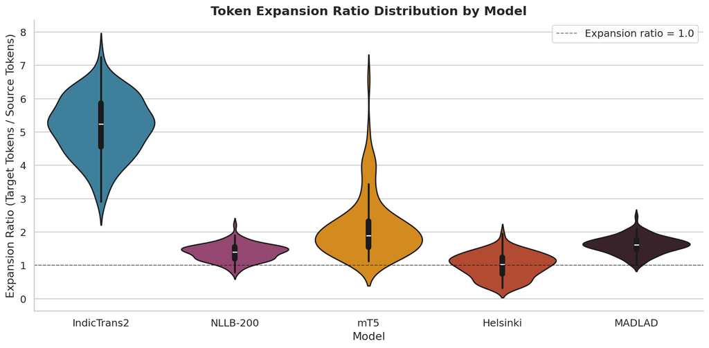

```python
# ── Cell 8 · VIZ B3 · Violin plot (expansion ratio distribution) ──────────────
fig, ax = plt.subplots(figsize=(12, 6))
sns.violinplot(
    data=token_df, x="model", y="expansion_ratio",
    order=list(MODEL_COLORS.keys()),
    palette=MODEL_COLORS, inner="box", linewidth=1.5, ax=ax,
)
ax.axhline(1.0, color="black", linestyle="--", linewidth=1, alpha=0.5, label="Expansion ratio = 1.0")
ax.set_title("Token Expansion Ratio Distribution by Model", fontsize=15, fontweight="bold")
ax.set_xlabel("Model")
ax.set_ylabel("Expansion Ratio (Target Tokens / Source Tokens)")
ax.legend()
plt.tight_layout()
plt.savefig("plots/partb_violin_expansion.png", bbox_inches="tight", dpi=150)
plt.show()
```

## VIZ B4 · Heatmap — Model × Metric Summary

**Purpose:** An executive-summary table of all four tokenisation metrics across all five models. Each cell shows the mean value across 100 sentences.

**Colour encoding — `RdYlGn_r` (reversed Red-Yellow-Green):** The `_r` suffix inverts the default colormap so that **red = high value, green = low value**. For three of the four metrics this maps intuitively to quality:

| Metric | Red (high) means | Green (low) means |
| --- | --- | --- |
| `expansion_ratio` | Many tokens per English word | Efficient, compact Tamil representation |
| `subword_fragmentation` | Aggressive splitting of Tamil words | Whole Tamil subwords retained |
| `unknown_token_rate` | Many out-of-vocabulary Tamil tokens | All Tamil text covered by vocabulary |
| `avg_word_length` | *(exception — higher is better here)* | Short tokens; over-segmented Tamil |

**Note on `avg_word_length`:** This is the only metric where the colour direction is inverted relative to quality — a red (high) cell for `avg_word_length` actually indicates better tokeniser behaviour. This is noted explicitly because `RdYlGn_r` is applied uniformly across all columns.

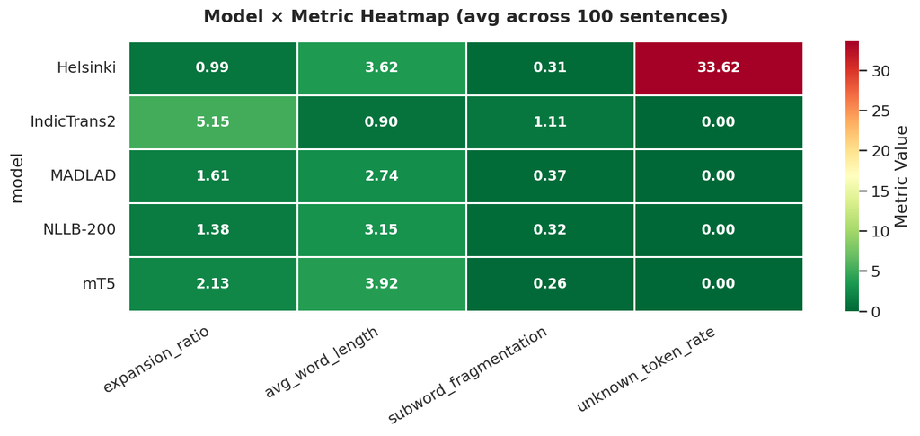

```python
# ── Cell 9 · VIZ B4 · Heatmap (model × metric summary) ───────────────────────
summary_display = token_df.groupby("model")[METRICS].mean().round(3)

fig, ax = plt.subplots(figsize=(11, 5))
sns.heatmap(
    summary_display, annot=True, fmt=".2f", cmap="RdYlGn_r",
    linewidths=0.5, linecolor="white", ax=ax,
    cbar_kws={"label": "Metric Value"}, annot_kws={"size": 11, "weight": "bold"},
)
ax.set_title(
    "Model \u00d7 Metric Heatmap (avg across 100 sentences)",
    fontsize=14, fontweight="bold", pad=15,
)
ax.set_xticklabels(ax.get_xticklabels(), rotation=30, ha="right")
ax.set_yticklabels(ax.get_yticklabels(), rotation=0)
plt.tight_layout()
plt.savefig("plots/partb_heatmap.png", bbox_inches="tight", dpi=150)
plt.show()
```